# Applied Algorithms

## Homework - 3

Team - Sricharraan Ramaswamy and Greeshma Sai Sree Duggireddy

Usernames - sriramas@iu.edu and grdugg@iu.edu

### All the wrok herein is solely mine

## Question - 1

Calculating the sum, product and the reciprocal sum

```python
def f(*x, **y):

    def sum1(x):
        s = 0
        if x:
            for i in x:
                s += i   # Calculating the sum of the numbers in the list
        return s

    def prod1(x):
        s = 1
        if x:
            for i in x:
                s *= i  # Calculating the product of the numbers in the list
        return s

    def reciprocal(x): # Calculating the reciprocal sum of the numbers in the list
        s = 0
        x = [i() for i in (lambda num = num:1/num for num in x)] # Using lambda, we calculate the sum of reciprocals
        return sum1(x) #Call the sum function


    if y["action"] == "sum":
        return sum1(*x)
    elif y["action"] == "prod":
        return prod1(*x)
    elif y["action"] == "reciprocal sum":
        return reciprocal(*x)
    else:
        return f"bad argument: {y}"


if __name__ == '__main__':

    xlst = [1,2,3,4,5]
    print("Sum : {}".format(f(xlst, action = "sum")))
    print("Product : {}".format(f(xlst, action = "prod")))
    print("Reciprocal sum : {}".format(f(xlst, action = "reciprocal sum")))
```

```
Sum : 15
Product : 120
Reciprocal sum : 2.283333333333333
```

## Question - 2

Using argparse and calculating the sum, product and the reciprocal sum

Once you run the code in the notebook it will only give the default value for that reason we have added a image file of the code giving output in the shell.

```python
import argparse
parser = argparse.ArgumentParser()
parser.add_argument('-lst', nargs='+', default = ['1'], help="Listofnumbers")
parser.add_argument('-op', default = 'sum', help = "sum, prod, rec")
parser.add_argument('-f')
args = parser.parse_args()

print(args.lst)
print(args.op)


def f(*x, **y):


    def sum1(x):
        s = 0
        if x:
            for i in x:
                s += i
        return s


    def prod1(x):
        s = 1
        if x:
            for i in x:
                s *= i
        return s

    def reciprocal(x):
        s = 0
        x = [i() for i in (lambda a = a:1/a for a in x)]
        print(x)
        return sum1(x)


    if y["action"] == "sum":
        return sum1(*x)
    elif y["action"] == "prod":
        return prod1(*x)
    elif y["action"] == "rec":
        return reciprocal(*x)
    else:
        return f"bad argument: {y}"


if __name__ == '__main__':

    xlst = args.lst
    xlst = list(map(int,xlst))
    print(f(xlst, action = args.op))
```

```
['1']
sum
1
```

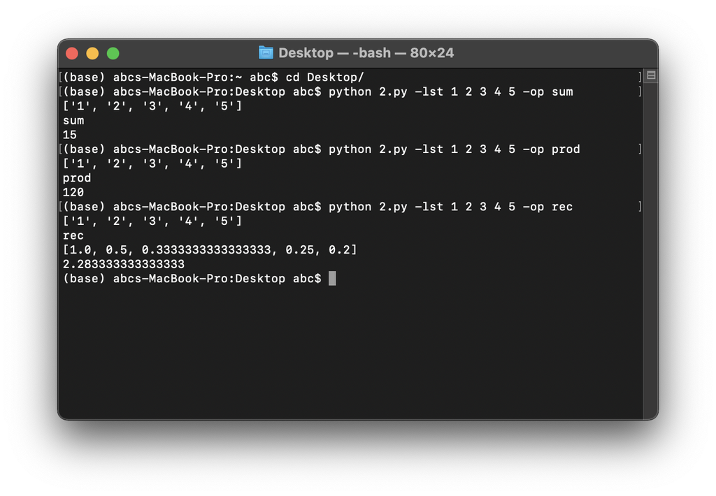

## Question - 3

In the example already given, the addition operator was overloaded to make the complex addition similar to the native type of addition.

Similarly, we write a cmul function for the multiplication of complex integers.

```python
class complex_:
    def __init__(self, re=0, im=0):
        self.re = re
        self.im = im

    def get_re(self):
        return self.re

    def get_im(self):
        return self.im

    def __str__(self):
        g = lambda x:"+" if x >= 0 else ""
        return f"({self.re}{g(self.im)}{self.im}i)"

    def cadd(self, other):
        new_re = self.get_re() + other.get_re()
        new_im = self.get_im() + other.get_im()
        return complex_(new_re, new_im)

    def __add__(self, other):
        new_re = self.get_re() + other.get_re()
        new_im = self.get_im() + other.get_im()
        return complex_(new_re, new_im)

    def cmul(self, other):
        new_re = (self.get_re() * other.get_re())- (self.get_im() * other.get_im())
        new_im = (self.get_re() * other.get_im())+ (self.get_im() * other.get_re())
        return complex_(new_re, new_im)

    def __mul__(self, other):
        new_re = (self.get_re() * other.get_re())- (self.get_im() * other.get_im())
        new_im = (self.get_re() * other.get_im())+ (self.get_im() * other.get_re())
        return complex_(new_re, new_im)


if __name__ == '__main__':

    w = complex_(1,-3)
    x = complex_(-1,3)
    y = complex_(1,3)
    z = complex_(-1,-3)
    print("Input values 1:{}" .format(w))
    print("Input values 2:{}" .format(x))
    print("Input values 3:{}" .format(y))
    print("Input values 4:{}" .format(z))

    print("Sum using function from class complex:{}".format(w.cadd(x).cadd(y).cadd(z)))
    print("Multiplication using function from class complex :{}".format(w.cmul(x).cmul(y).cmul(z)))
    print("Sum just putting values in print() :{}".format((1-3j) + (-1+3j) + (1+3j) + (-1-3j)))
    print("Multiplication just putting values in print() :{}".format((1-3j) * (-1+3j) * (1+3j) * (-1-3j)))
    print("Sum using variables :{}".format(w + x + y + z))
    print("Multiplication using variables :{}".format(w * x * y * z))
```

```
Input values 1:(1-3i)
Input values 2:(-1+3i)
Input values 3:(1+3i)
Input values 4:(-1-3i)
Sum using function from class complex:(0+0i)
Multiplication using function from class complex :(100+0i)
Sum just putting values in print() :0j
Multiplication just putting values in print() :(100+0j)
Sum using variables :(0+0i)
Multiplication using variables :(100+0i)
```

## Question - 4

We are taking a list 'I' here and appending it with the value from 1 to 2 power 10.

In the list S1, we append random integers using randint() function for the 3 algorithms.

For the three algorithms given, we take three lists - end1, end2, end3.

We append the running time of each algorithm to the respective lists.

Using log-log scale for the graph, we plot the input size vs run time of each algorithm in the graph using matplotlib.

```python
#Algorithm - 1
#Time complexity - O(n^2)
def average1(S):
    n = len(S)
    my_average = [0] * n
    for j in range(n):
        total = 0
        for i in range(j + 1):
            total += S[i]
        my_average[j] = total / (j+1)
    return my_average
```

```python
#Algorithm - 2
#Time complexity - O(n)
def average2(S):
    n = len(S)
    my_average= [0] * n
    for j in range(n):
        my_average[j] = sum(S[0:j+1]) / (j+1)
    return my_average
```

```python
#Algorithm - 3
#Time complexity - O(n)
def average3(S):
    n = len(S)
    my_average = [0] * n
    total = 0
    for j in range(n):
        total += S[j]
        my_average[j] = total / (j+1)
    return my_average
```

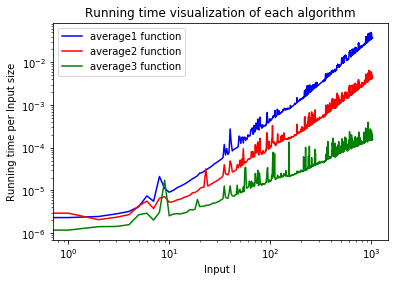

```python
import random as r
import matplotlib.pyplot as plt
from timeit import default_timer

I = [] #Input Size

for i in range(pow(2,10)):
    I.append(i)
end1 = []  #Runtime for Algorithm - 1
end2 = []  #Runtime for Algorithm - 2
end3 = []  #Runtime for Algorithm - 3
S1 = []

for j in I:
    for i in range(j):
        S1.append(r.randint(0,4000))

    #Algorithm - 1
    start1 = default_timer()
    avg = average1(S1)
    end1.append((default_timer()-start1))
    #Algorithm - 2
    start2 = default_timer()
    avg = average2(S1)
    end2.append((default_timer()-start2))
    #Algorithm - 3
    start3 = default_timer()
    avg = average3(S1)
    end3.append((default_timer()-start3))
    S1.clear()

#Plotting the log-log graph
plt.xscale('log')
plt.yscale('log')
plt.xlabel('Input I')
plt.ylabel('Running time per Input size')
plt.title('Running time visualization of each algorithm')
plt.plot(I,end1, color = 'b', label = 'average1 function')
plt.plot(I,end2, color = 'r', label = 'average2 function')
plt.plot(I,end3, color = 'g', label = 'average3 function')
plt.legend()
```

## Question - 5

According to our understanding each algorithm returns true if there are unique elements in the list else it will return false.

For the largest value of input size, the values in the list should be unique i.e. worst case scenario.

Since, randint() function will generate random numbers and there is a possibility of two numbers getting repeated.

Therefore, the value of list 'S' will have values from 1 to the input size which will make the list unique.

Once we have calculated the run time of algorithm1, we have plotted a Running time visualization graph for the same and have used interp() function(in numpy class) to find the most accurate largest value of input size.

```python
def algorithm1(S):
    #S:sequence
    for j in range(len(S)):
        for k in range(j+1, len(S)):
             if S[j] == S[k]:
                    return False
    return True
```

```
The largest input size is 30000 and the running time for the same is 33.616679573
The largest input size with accuracy (from the graph): 34594
```

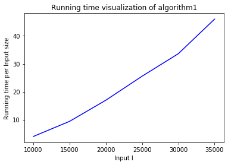

```python
import matplotlib.pyplot as plt
from timeit import default_timer
import numpy as np
Is = []
If1 = []
S = []
end1  = []
j = 1
for i in range(10000,50000,5000):
    Is.append(i)
#print(Is)
while (j>0):
     for i in Is:
            for k in range(i):
                S.append(k)
            start1 = default_timer()
            algo1 = algorithm1(S)
            end1.append(default_timer()-start1)
            If1.append(i)
            #print(If1)
            #print(end1)
            if (end1[-1] > 45):
                ans = If1[-2]
                best_time = end1[-2]
                j = 0
                break
            S.clear()
print("The largest input size is {} and the running time for the same is {}".format(ans,best_time))
plt.xlabel('Input I')
plt.ylabel('Running time per Input size')
plt.title('Running time visualization of algorithm1')
plt.plot(If1,end1, color = 'b')
print("The largest input size with accuracy (from the graph): {}".format(int(np.interp(45, end1, If1))))
```

Once we have calculated the run time of algorithm2, we have plotted a Running time visualization graph for the same and have used interp() function(in numpy class) to find the most accurate largest value of input size.

```python
def algorithm2(S):
    S = sorted(S)
    for j in range(1, len(S)):
        if S[j-1] == S[j]:
            return False
    return True
```

```
The largest input size is 250000000 and the running time for the same is 38.757560619999936
The largest input size with accuracy (from the graph): 282443910
```

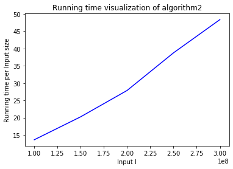

```python
import matplotlib.pyplot as plt
from timeit import default_timer
import numpy as np
Is = []
If2 = []
S = []
end2  = []
j = 1
for i in range(100000000,500000000,50000000):
    Is.append(i)
#print(Is)
while (j>0):
     for i in Is:
            for k in range(i):
                S.append(k)
            start1 = default_timer()
            algo1 = algorithm2(S)
            end2.append(default_timer()-start1)
            If2.append(i)
            #print(If2)
            #print(end2)
            if (end2[-1] > 45):
                ans = If2[-2]
                best_time = end2[-2]
                j = 0
                break
            S.clear()
print("The largest input size is {} and the running time for the same is {}".format(ans,best_time))
plt.xlabel('Input I')
plt.ylabel('Running time per Input size')
plt.title('Running time visualization of algorithm2')
plt.plot(If2,end2, color = 'b')
print("The largest input size with accuracy (from the graph): {}".format(int(np.interp(45, end2, If2))))
```

In algorithm3 we can clearly see that the time complexity is much higher than any of the cases i.e. O(2^n) and therefore after trying for values 1-20 we saw that the run time was less than 1 sec, which led us to started appending values from 1 to 50 with a step size of 2.

Once we have calculated the run time of algorithm3, we have plotted a Running time visualization graph for the same and have used interp() function(in numpy class) to find the most accurate largest value of input size.

```python
def algorithm3(S, start, stop):
    if stop - start <= 1: return True
    elif not algorithm3(S, start, stop-1): return False
    elif not algorithm3(S, start+1, stop): return False
    else: return S[start] != S[stop-1]
```

```
The largest input size is 27 and the running time for the same is 21.751520524999933
The largest input size with accuracy (from the graph): 27
```

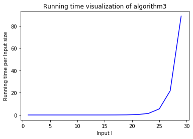

```python
import matplotlib.pyplot as plt
from timeit import default_timer
import numpy as np
Is = []
If = []
S = []
end  = []
j = 1
for i in range(1,50,2):
    Is.append(i)
#print(Is)
while (j>0):
     for i in Is:
            for k in range(i):
                S.append(k)
            start1 = default_timer()
            algo1 = algorithm3(S,0,i)
            end.append(default_timer()-start1)
            If.append(i)
            #print(If)
            #print(end)
            if (end[-1] > 45):
                ans = If[-2]
                best_time = end[-2]
                j = 0
                break
            S.clear()
print("The largest input size is {} and the running time for the same is {}".format(ans,best_time))
plt.xlabel('Input I')
plt.ylabel('Running time per Input size')
plt.title('Running time visualization of algorithm3')
plt.plot(If,end, color = 'b')
print("The largest input size with accuracy (from the graph): {}".format(int(np.interp(45, end, If))))
```

We have plotted a log-log graph of all the three algorithms for comparison and to draw conclusions i.e. for large amount data algorithm 2 is the best.

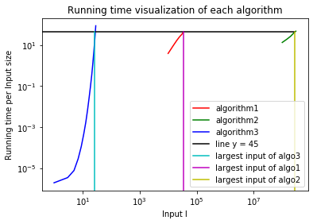

```python
import math
x =[0,int(np.interp(45, end2, If2))]
z =[45,45]
z1 = [int(np.interp(45, end, If)),int(np.interp(45, end, If))]
z2 = [int(np.interp(45, end1, If1)),int(np.interp(45, end1, If1))]
z3 = [int(np.interp(45, end2, If2)),int(np.interp(45, end2, If2))]
y = [0,45]
plt.xscale('log')
plt.yscale('log')
plt.xlabel('Input I')
plt.ylabel('Running time per Input size')
plt.title('Running time visualization of each algorithm')
plt.plot(If1,end1, color = 'r', label = 'algorithm1')
plt.plot(If2,end2, color = 'g', label = 'algorithm2')
plt.plot(If,end, color = 'b', label = 'algorithm3')
plt.plot(x,z, color = 'k', label = 'line y = 45')
plt.plot(z1,y, color = 'c', label = 'largest input of algo3')
plt.plot(z2,y, color = 'm', label = 'largest input of algo1')
plt.plot(z3,y, color = 'y', label = 'largest input of algo2')
plt.legend()
```